# Prediction Assignment Writeup

Ivan Vemado Marques

21/01/2020

## Instructions

One thing that people regularly do is quantify how much of a particular activity they do, but they rarely quantify how well they do it. In this project, your goal will be to use data from accelerometers on the belt, forearm, arm, and dumbell of 6 participants.

*The goal of your project is to predict the manner in which they did the exercise.*

## Loading and Tidying

Let’s beginning with some exploratory data analysis. But first we need load some packages for working with dat and load the training dataset.

*Data*

The training data for this project are available here:

https://d396qusza40orc.cloudfront.net/predmachlearn/pml-training.csv

The test data are available here:

https://d396qusza40orc.cloudfront.net/predmachlearn/pml-testing.csv

The data for this project come from this source: http://web.archive.org/web/20161224072740/http:/groupware.les.inf.puc-rio.br/har

```r
##install.packages("ggplot2", dependencies = T)
##install.packages("caret", dependencies = T)
##install.packages("gbm", dependencies = T)
##install.packages("corrplot", dependencies = T)
##install.packages("rattle", dependencies = T)
##install.packages("rpart", dependencies = T)
##install.packages("rpart.plot", dependencies = T)

library(ggplot2)
library(caret)
library(gbm)
library(corrplot)
library(rattle)
library(rpart)
library(rpart.plot)
```

Let’s see a little bit of the structure of dataset training.

```r
training <- read.csv("~/Desktop/R/pml-training.csv")

head(training)
tail(training)

str(training)
```

[output not shown]

Let’s make a tidy dataset. Removing the variables with Nearly Zero Variance and with many NA observations.

```r
training <- training[, -nearZeroVar(training)]

nulls    <- sapply(training, function(x) mean(is.na(x))) > 0.9
training <- training[, nulls == FALSE]
```

```r
head(training)
str(training)
```

[output not shown]

Still we need to remove the rest of ID variables in the dataset.

```r
training <- training[, -(1:5)]
```

```r
head(training)
str(training)
```

[output not shown]

## Preparing dataset

Now, we need to set a seed for the research become reproducible. After we will create the partition of validation.

```r
set.seed(12345)

inTrain <- createDataPartition(training$classe, p = 0.7, list = FALSE)
trainds <- training[inTrain, ]
testds <- training[-inTrain, ]
```

## Correlations

Here we need to evaluate the correlations of the variables to decide if we will use PCA as pre-processing method for modeling.

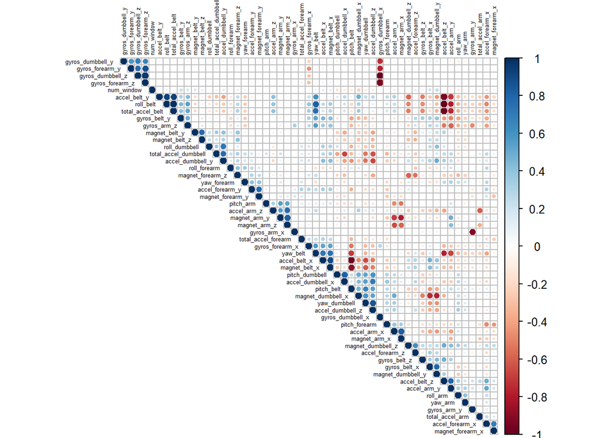

```r
mcor <- cor(trainds[, -54])
corrplot(mcor, type = "upper", order = "hclust", tl.col = "black", tl.cex = 0.4)
```

How they have few correlations, we will maintain all variables to modeling.

Now we will run three methods of modeling for the classification problem and the predictions of them with cross-validation technique to improve accuracy. Through a Confusion Matrix we can compare the accuracy of the models.

```r
#Setting Cross-Validation method
trCtrl <- trainControl(method="cv", number=5, verboseIter=FALSE)

#Random Forest
fit_rf <- train(classe ~ ., data = trainds, method = "rf", trControl=trCtrl)
pr_rf <- predict(fit_rf, newdata=testds)

#Gradient Boosting
fit_gbm <- train(classe ~ ., data = trainds, method = "gbm", trControl=trCtrl, verbose = FALSE)
pr_gbm <- predict(fit_gbm, newdata=testds)

#Linear Discriminant Analysis
fit_lda <- train(classe ~ ., data = trainds, method = "lda", trControl=trCtrl, verbose = FALSE)
pr_lda <- predict(fit_lda, newdata=testds)

#Confusion Matrix
confusionMatrix(pr_rf, testds$classe)$overall[1]
```

```
##  Accuracy
## 0.9962617
```

```r
confusionMatrix(pr_gbm, testds$classe)$overall[1]
```

```
##  Accuracy
## 0.9840272
```

```r
confusionMatrix(pr_lda, testds$classe)$overall[1]
```

```
##  Accuracy
## 0.7070518
```

### Conclusion

*After analysis, the Random Forest regression model was better fitting with accuracy 0.996 than others Gradient Boosting (0.984) and Linear Discriminant Analysis (0.707). So, let’s see the plot of them:*

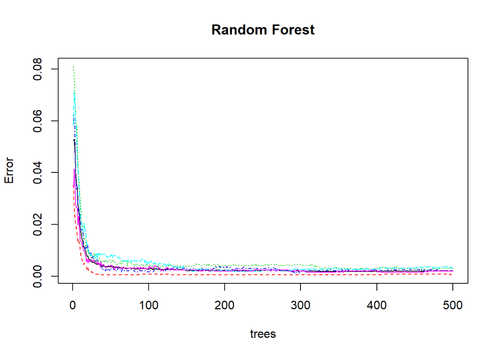

```r
plot(fit_rf$finalModel, main = "Random Forest")
```

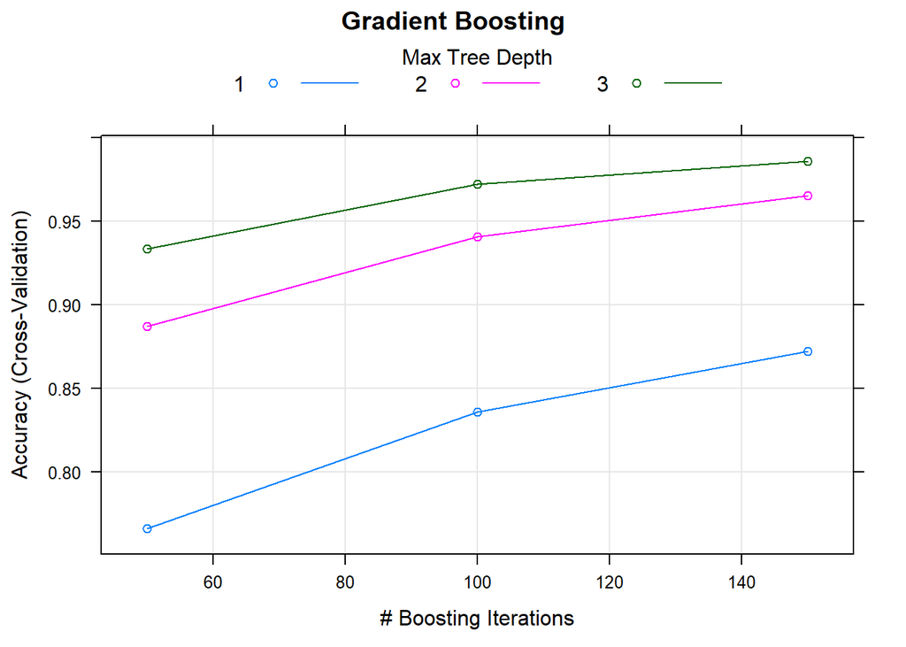

```r
plot(fit_gbm, main = "Gradient Boosting")
```

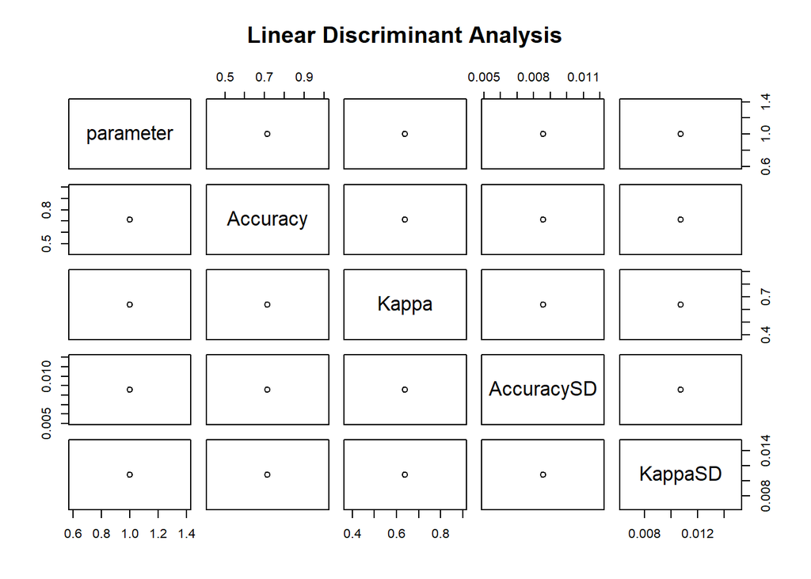

```r
plot(fit_lda$results, main = "Linear Discriminant Analysis")
```